# Lab 9: Data Science to Solve Problems and Answer Questions, part 2

Brian Teklits, Charles Doremieux, Andrew MacLean, Clint LaBattaglia

10/25/2019

### Dataset and Questions

**Overall question and it’s importance:** What candies are the most universally liked and disliked?

Understanding which candies are the most popular informs us of what qualities to keep in mind when designing a new candy.

**Why the answer matters:** There are a variety of conclusions which can be drawn depending on who the company wants their new product to target. Universally liked candies offer a safe bet, universally disliked offer some qualities to avoid, while those in between could represent somewhat effective ideas which can be improved upon.

**Conclusions:** The score variable describes the total number of likes (+1) and dislikes (-1) a candy received. Positive scores indicate candies that were liked overall, negatives indicate candies that were disliked overall. The highest scoring candies were:

```r
candy3 <- candy2 %>%
  group_by(`Candy Type`) %>%
  filter(!is.na(Rating)) %>%
  summarize(Score = sum(Rating)) %>%
  arrange(desc(Score))
candy3 %>%
  top_n(10)
```

```
## # A tibble: 10 x 2
##    `Candy Type`                 Score
##    <chr>                        <dbl>
##  1 Reeses                        1403
##  2 Kit Kat                       1395
##  3 Twix                          1342
##  4 Snickers                      1320
##  5 Tolberone something or other  1236
##  6 Lindt Truffle                 1179
##  7 Peanut M&Ms                   1170
##  8 Nestle Crunch                 1086
##  9 Milky Way                     1083
## 10 Dove Bars                     1068
```

The 10 lowest scoring:

```r
candy3 %>%
  arrange(Score)
```

```
## # A tibble: 79 x 2
##    `Candy Type`                                    Score
##    <chr>                                           <dbl>
##  1 Gum from baseball cards                         -1418
##  2 Those odd marshmallow circus peanut things      -1063
##  3 Box'o'Raisins                                   -1062
##  4 Spotted Dick                                    -1012
##  5 Jolly Rancher (bad flavor)                       -963
##  6 Sandwich-sized bags filled with BooBerry Crunch  -940
##  7 Mary Janes                                       -913
##  8 JoyJoy (Mit Iodine!)                             -880
##  9 Peeps                                            -846
## 10 Black Jacks                                      -701
## # … with 69 more rows
```

The candies receiving the most likes and dislikes follow the above summaries more or less. The candies receiving the most “Meh” ratings were:

```r
candy2 %>%
  filter(Rating == 0) %>%
  group_by(`Candy Type`) %>%
  summarize(Meh = n()) %>%
  arrange(desc(Meh))
```

```
## # A tibble: 79 x 2
##    `Candy Type`          Meh
##    <chr>               <int>
##  1 Lollipops             931
##  2 Hard Candy            907
##  3 Bonkers (the candy)   857
##  4 Minibags of chips     759
##  5 100 Grand Bar         755
##  6 Chiclets              744
##  7 LaffyTaffy            729
##  8 Tic Tacs              728
##  9 Hershey's Kisses      726
## 10 Now'n'Laters          725
## # … with 69 more rows
```

Lastly, the candies which received the most non-responses:

```r
candy2 %>%
  filter(is.na(Rating)) %>%
  group_by(`Candy Type`) %>%
  summarize(count = n()) %>%
  arrange(desc(count))
```

```
## # A tibble: 79 x 2
##    `Candy Type`                               count
##    <chr>                                      <int>
##  1 JoyJoy (Mit Iodine!)                        1026
##  2 Maynards                                    1024
##  3 Reggie Jackson Bar                          1014
##  4 Sweetums (a friend to diabetes)             1002
##  5 Bonkers (the candy)                          992
##  6 Black Jacks                                  958
##  7 Chick-o-Sticks (we dont know what that is)   946
##  8 Kinder Happy Hippo                           945
##  9 Take 5                                       917
## 10 Smarties (Commonwealth)                      901
## # … with 69 more rows
```

The overall distribution of Scores for candies:

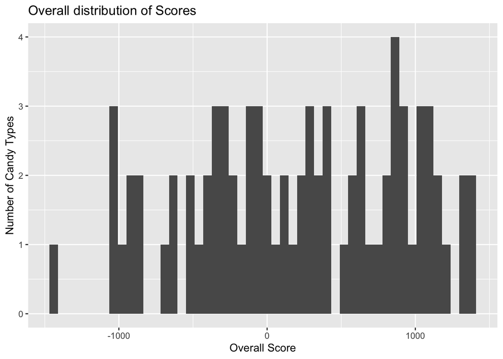

```r
ggplot(candy3) +
  geom_histogram(aes(Score),bins=50)+
  ylab("Number of Candy Types")+
  xlab("Overall Score")+
  ggtitle("Overall distribution of Scores")
```

**Recommendations:** The most popular candies all contain chocolate paired with some other flavor. A safe bet for a new product is to start with chocolate and experiment with adding additional flavors. Hard candies tend to be less popular overall, so if designing a new hard candy, it should target a specific group. (i.e. a sour, hard candy could be popular among younger age groups)

We also found that:

- Preferences for candy don’t significantly vary among genders.
- Sour candies should only be designed with a younger audience in mind, as we found that older demographics dislike sour flavors.
- The top candies are similar in various regions of the US and Internationally, but outside the top 5 there is some variety in preferences. So, there is some indication that regionally targetted candy choices would be successful.
- The favorite and least favorite candies are similar but display noticable differences between countries. All countries tend to hate the same candy and prefer chocolate over sour and sweet candy.

**Description of Dataset:** This dataset came from an internet survey, where users could input whatever they wanted for age, country, state and gender. As a result, the majority of the work tidying this dataset was converting the many different responses for each category into a single name, so they could be more easily grouped.

For the candy related questions, only 3 inputs were allowed: “Despair”, “Meh”, and “Joy”. Once the various inputs were grouped properly, the candy inputs were converted to -1, 0, and 1 respectively, so they could be easily summed.

Then, we dropped the irrelevant columns and gathered the candy data into a single column. The dataset is now tidy and ready to be analyzed.

Finally, we ran summaries on the various demographics of the dataset, generated the score variable to compare overall preferences among candy types, and ran a variety of filters to focus on subsets of the data, both for summaries and plots.

### Individual Findings and Plots

#### Andrew

**Andrew’s Question:** Are certain candies more likely to be popularized and disliked by Country?

First, I separted the candy data set into 3 different data sets based upion which country the person was from. This will allows us to compare the most popular candies as well as those that were the most disliked.

```r
UScandy <- candy2 %>%
  filter(COUNTRY == 'United States', !is.na(Rating)) %>%
  group_by(`Candy Type`) %>%
  summarize(Rating = sum(Rating)) %>%
  arrange(desc(Rating))
topUS <- UScandy %>%
  top_n(10)

Ukcandy <- candy2 %>%
  filter(COUNTRY == 'United Kingdom', !is.na(Rating)) %>%
  group_by(`Candy Type`) %>%
  summarize(Rating = sum(Rating)) %>%
  arrange(desc(Rating))
topUk <- Ukcandy %>%
  top_n(10)

Ccandy <- candy2 %>%
  filter(COUNTRY == 'Canada', !is.na(Rating)) %>%
  group_by(`Candy Type`) %>%
  summarize(Rating = sum(Rating)) %>%
  arrange(desc(Rating))
topC <- Ccandy %>%
  top_n(10)
```

Now that we know the favorite candies for each country, it would be also interesting to analyze the least favorite candies.

```r
dlUS <- candy2 %>%
  filter(Rating == -1, COUNTRY =="United States") %>%
  group_by(`Candy Type`) %>%
  summarize( Disliked = n()) %>%
  arrange(desc(Disliked))

dlUk <- candy2 %>%
  filter(Rating == -1, COUNTRY =="United Kingdom") %>%
  group_by(`Candy Type`) %>%
  summarize( Disliked = n()) %>%
  arrange(desc(Disliked))

dlC <- candy2 %>%
  filter(Rating == -1, COUNTRY =="Canada") %>%
  group_by(`Candy Type`) %>%
  summarize( Disliked = n()) %>%
  arrange(desc(Disliked))
```

It was interesting to find that every country hates gum from baseball cards, little marshmellows from circus peanuts, and Box’o’raisins. Although there were less entries for Canada and United Kingdom, it was interesting to notice that each had similar favorites and least favorites.

```r
topUS %>%
  ggplot(aes(x = reorder(`Candy Type`, Rating), y = Rating))+
  geom_col(stat = "identity") +
  ggtitle("United States Favorite Candies")+
  xlab("Candy")+
  ylab("Number of People")+
  coord_flip()

topUk %>%
  ggplot(aes(x = reorder(`Candy Type`, Rating), y = Rating))+
  geom_col(stat = "identity") +
  ggtitle("United Kingdoms Favorite Candies")+
  xlab("Candy")+
  ylab("Number of People")+
  coord_flip()

topC %>%
  ggplot(aes(x = reorder(`Candy Type`, Rating), y = Rating))+
  geom_col(stat = "identity") +
  ggtitle("Canada's Favorite Candies")+
  xlab("Candy")+
  ylab("Number of People")+
  coord_flip()
```

[output not shown]

#### Brian

**Brian’s Question:** Which candies are the most and least polarizing (liked by one age group and disliked by another)?

First, ages needed to be consolidated into groups:

```r
candy <- candy %>%
  mutate(AgeRange = cut(AGE,
                        breaks=c(-Inf, 20, 25, 30, 35, 40, 45, 50, 55, 60, Inf),
                        labels=c("Under 20", "20-25", "25-30", "30-35", "35-40", "40-45", "45-50", "50-55", "55-60", "Over 60")))
```

The age demographics of the dataset are:

```r
(Responses_per_Agegroup <- candy %>%
  group_by(AgeRange) %>%
  filter(!is.na(AgeRange)) %>%
  summarize(Responses = n()))
```

```
## # A tibble: 10 x 2
##    AgeRange Responses
##    <fct>        <int>
##  1 Under 20        81
##  2 20-25           69
##  3 25-30          194
##  4 30-35          355
##  5 35-40          411
##  6 40-45          390
##  7 45-50          329
##  8 50-55          216
##  9 55-60          162
## 10 Over 60        159
```

The age groups vary in size, so a new variable is made based on the average score given per respondent in a given group. Votes of 0 and NA are equivalent for this calculation, as only dislikes and likes influence the score variable. Since 0 signifies indifference, it seems reasonable to equate non-answers to indifference (or no opinion) on a given candy.

```r
Score_per_Agegroup <- candy2 %>%
  group_by(AgeRange,`Candy Type`) %>%
  filter(!is.na(Rating) & !is.na(AgeRange)) %>%
  summarize(Score = sum(Rating))

(Score_over_Responses <- left_join(Score_per_Agegroup, Responses_per_Agegroup, by="AgeRange") %>%
  mutate(AvgScore = Score/Responses) %>%
  arrange(desc(AvgScore)))
```

```
## # A tibble: 790 x 5
## # Groups:   AgeRange [10]
##    AgeRange `Candy Type`                 Score Responses AvgScore
##    <fct>    <chr>                        <dbl>     <int>    <dbl>
##  1 45-50    Reeses                         218       329    0.663
##  2 50-55    Kit Kat                        139       216    0.644
##  3 50-55    Reeses                         137       216    0.634
##  4 50-55    Tolberone something or other   137       216    0.634
##  5 45-50    Kit Kat                        208       329    0.632
##  6 45-50    Twix                           207       329    0.629
##  7 35-40    Twix                           256       411    0.623
##  8 40-45    Reeses                         237       390    0.608
##  9 Under 20 Kit Kat                         49        81    0.605
## 10 55-60    Kit Kat                         98       162    0.605
## # … with 780 more rows
```

Finally, to get an idea for how preferences differ among ages, we look at the range of average scores for each candy:

```r
(Score_Range <- Score_over_Responses %>%
  group_by(`Candy Type`) %>%
  summarize(ScoreRange = max(AvgScore)-min(AvgScore)) %>%
  arrange(desc(ScoreRange)))
```

```
## # A tibble: 79 x 2
##    `Candy Type`                                    ScoreRange
##    <chr>                                                <dbl>
##  1 Sourpatch Kids                                       0.827
##  2 Nerds                                                0.596
##  3 Peeps                                                0.559
##  4 Whatchamacallit Bars                                 0.529
##  5 Lollipops                                            0.509
##  6 Bottle Caps                                          0.481
##  7 Sandwich-sized bags filled with BooBerry Crunch      0.458
##  8 Kinder Happy Hippo                                   0.455
##  9 Jolly Ranchers (good flavor)                         0.452
## 10 Tic Tacs                                             0.426
## # … with 69 more rows
```

Sourpatch Kids stand out as highly divisive:

```r
Score_over_Responses %>%
  filter(`Candy Type` == "Sourpatch Kids")
```

```
## # A tibble: 10 x 5
## # Groups:   AgeRange [10]
##    AgeRange `Candy Type`   Score Responses AvgScore
##    <fct>    <chr>          <dbl>     <int>    <dbl>
##  1 Under 20 Sourpatch Kids    34        81   0.420
##  2 20-25    Sourpatch Kids    28        69   0.406
##  3 30-35    Sourpatch Kids   119       355   0.335
##  4 25-30    Sourpatch Kids    65       194   0.335
##  5 35-40    Sourpatch Kids   118       411   0.287
##  6 40-45    Sourpatch Kids    52       390   0.133
##  7 45-50    Sourpatch Kids   -12       329  -0.0365
##  8 50-55    Sourpatch Kids   -31       216  -0.144
##  9 Over 60  Sourpatch Kids   -45       159  -0.283
## 10 55-60    Sourpatch Kids   -66       162  -0.407
```

Distaste for Sourpatch Kids increases with age: the youngest age groups like them overall, as we increase through the age groups, respondents begin to dislike them overall with increasing regularity.

The least divisive candies:

```r
Score_Range %>% arrange(ScoreRange)
```

```
## # A tibble: 79 x 2
##    `Candy Type`                               ScoreRange
##    <chr>                                           <dbl>
##  1 Peanut M&Ms                                     0.102
##  2 Smarties (Commonwealth)                         0.120
##  3 Mary Janes                                      0.138
##  4 Those odd marshmallow circus peanut things      0.144
##  5 Nestle Crunch                                   0.160
##  6 LemonHeads                                      0.160
##  7 Junior Mints                                    0.162
##  8 Milk Duds                                       0.163
##  9 Regular M&Ms                                    0.165
## 10 Kit Kat                                         0.166
## # … with 69 more rows
```

Peanut M&Ms are liked by all groups, with little difference in scores:

```r
Score_over_Responses %>%
  filter(`Candy Type` == "Peanut M&Ms")
```

```
## # A tibble: 10 x 5
## # Groups:   AgeRange [10]
##    AgeRange `Candy Type` Score Responses AvgScore
##    <fct>    <chr>        <dbl>     <int>    <dbl>
##  1 55-60    Peanut M&Ms     85       162    0.525
##  2 45-50    Peanut M&Ms    171       329    0.520
##  3 40-45    Peanut M&Ms    202       390    0.518
##  4 50-55    Peanut M&Ms    109       216    0.505
##  5 35-40    Peanut M&Ms    205       411    0.499
##  6 Over 60  Peanut M&Ms     76       159    0.478
##  7 Under 20 Peanut M&Ms     36        81    0.444
##  8 30-35    Peanut M&Ms    155       355    0.437
##  9 20-25    Peanut M&Ms     30        69    0.435
## 10 25-30    Peanut M&Ms     82       194    0.423
```

Visualizing the Average scores of some notable candies:

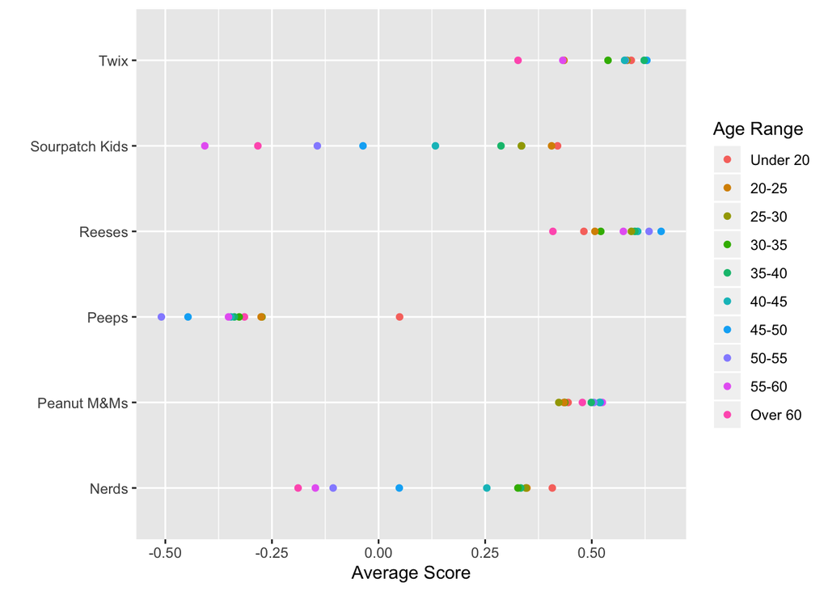

```r
Notable_Candy <- Score_over_Responses %>%
  filter(`Candy Type` == "Peanut M&Ms"|`Candy Type` == "Sourpatch Kids"|`Candy Type` == "Nerds"|`Candy Type` == "Twix"| `Candy Type` == "Peeps"|`Candy Type` == "Reeses")
ggplot(Notable_Candy)+
  geom_point(aes(AvgScore,`Candy Type`,color=AgeRange))+
  ylab("")+
  xlab("Average Score")+
  scale_color_discrete("Age Range")
```

So, we conclude that sour candies should be made with younger people in mind, while chocolate and nut combinations seem to be universally popular.

**Reflections:** Whenever a product’s target demographic is children, care should be taken when advertising; the goal is to make something they enjoy while recognizing they lack the skills to moderate themselves properly.

#### Charles

**Charles’ Question:** Are there any candies which are predominantly popular to a particular sex/gender? Which candies, if any, are preferred predominantly by men or women?

The first task is to view the favorite candies of men and women. By filtering from the candies to find the 10 most popular for men and women we can begin to envision if men and women have similar tastes in candies.

```r
men_candy <- candy2 %>%
  filter(GENDER == 'Male', !is.na(Rating)) %>%
  group_by(`Candy Type`) %>%
  summarize(Score = sum(Rating)) %>%
  arrange(desc(Score))
mc <- men_candy %>%
  top_n(10)

mc
```

```
## # A tibble: 10 x 2
##    `Candy Type`                 Score
##    <chr>                        <dbl>
##  1 Reeses                         855
##  2 Kit Kat                        850
##  3 Snickers                       807
##  4 Twix                           797
##  5 Tolberone something or other   745
##  6 Peanut M&Ms                    731
##  7 Nestle Crunch                  690
##  8 Lindt Truffle                  672
##  9 Milky Way                      650
## 10 Butterfinger                   634
```

```r
women_candy <- candy2 %>%
  filter(GENDER == 'Female',!is.na(Rating)) %>%
  group_by(`Candy Type`) %>%
  summarize(Score = sum(Rating)) %>%
  arrange(desc(Score))
wc <- women_candy %>%
  top_n(10)

wc
```

```
## # A tibble: 10 x 2
##    `Candy Type`                 Score
##    <chr>                        <dbl>
##  1 Twix                           476
##  2 Reeses                         474
##  3 Kit Kat                        471
##  4 Lindt Truffle                  449
##  5 Snickers                       445
##  6 Tolberone something or other   430
##  7 Dove Bars                      404
##  8 Peanut M&Ms                    385
##  9 Milky Way                      378
## 10 Regular M&Ms                   376
```

Overall the top candy choices of men and women are highly similar. 4 of the top 5 candies for men and women are identical. There is some preference from women to eat candied bars, but overall the difference between men and women’s tastes in candy is not significant when viewing their favorite candies. This observation leads to a different question. If men and women like the same candies, do they also dislike the same candies.

```r
lf_m <- candy2 %>%
  filter(Rating == -1, GENDER == 'Male') %>%
  group_by(`Candy Type`) %>%
  summarize(Dislike = n()) %>%
  arrange(desc(Dislike))

lf_m
```

```
## # A tibble: 79 x 2
##    `Candy Type`                                    Dislike
##    <chr>                                             <int>
##  1 Gum from baseball cards                             883
##  2 Those odd marshmallow circus peanut things          731
##  3 Box'o'Raisins                                       704
##  4 Spotted Dick                                        684
##  5 Sandwich-sized bags filled with BooBerry Crunch     675
##  6 Peeps                                               667
##  7 Mary Janes                                          649
##  8 Jolly Rancher (bad flavor)                          619
##  9 JoyJoy (Mit Iodine!)                                566
## 10 Trail Mix                                           516
## # … with 69 more rows
```

```r
lf_w <- candy2 %>%
  filter(Rating == -1, GENDER == 'Female') %>%
  group_by(`Candy Type`) %>%
  summarize(Dislike = n()) %>%
  arrange(desc(Dislike))

lf_w
```

```
## # A tibble: 79 x 2
##    `Candy Type`                                    Dislike
##    <chr>                                             <int>
##  1 Gum from baseball cards                             503
##  2 Those odd marshmallow circus peanut things          452
##  3 Box'o'Raisins                                       416
##  4 Sandwich-sized bags filled with BooBerry Crunch     412
##  5 Spotted Dick                                        399
##  6 Jolly Rancher (bad flavor)                          382
##  7 Mary Janes                                          369
##  8 Peeps                                               366
##  9 JoyJoy (Mit Iodine!)                                343
## 10 Licorice (yes black)                                340
## # … with 69 more rows
```

Men and Women also dislike the same candies at the same rate. The similarity of their dislike of certain foods is even more similar than their appreciation of those foods. Simply viewing the results provides no reason to believe that candies’ popularities are driven or correlated to the gender of the consumer. This is intuitive, because having a gender-neutral candy pushes sales onto both men and women, increasing profitability.

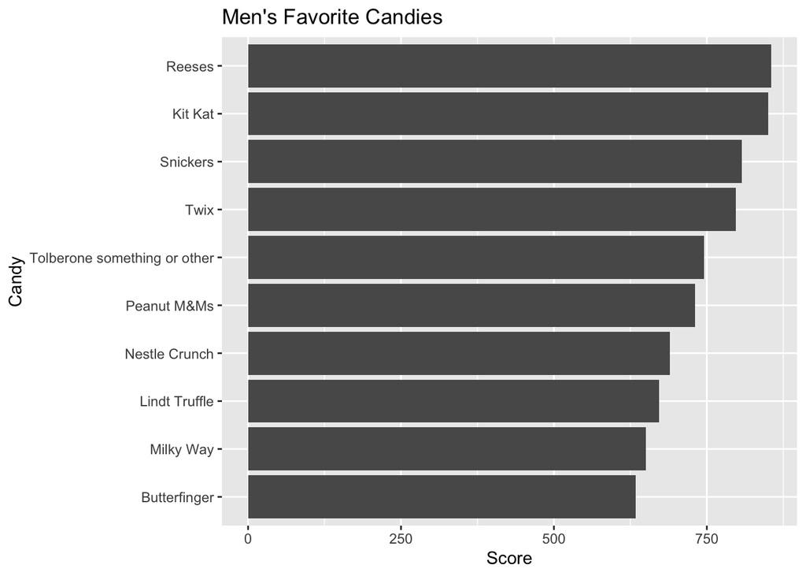

```r
mc %>%
  ggplot(aes(x = fct_reorder(`Candy Type`, Score), y = Score))+
  geom_bar(stat = "identity") +
  ggtitle("Men's Favorite Candies")+
  xlab("Candy")+
  coord_flip()
```

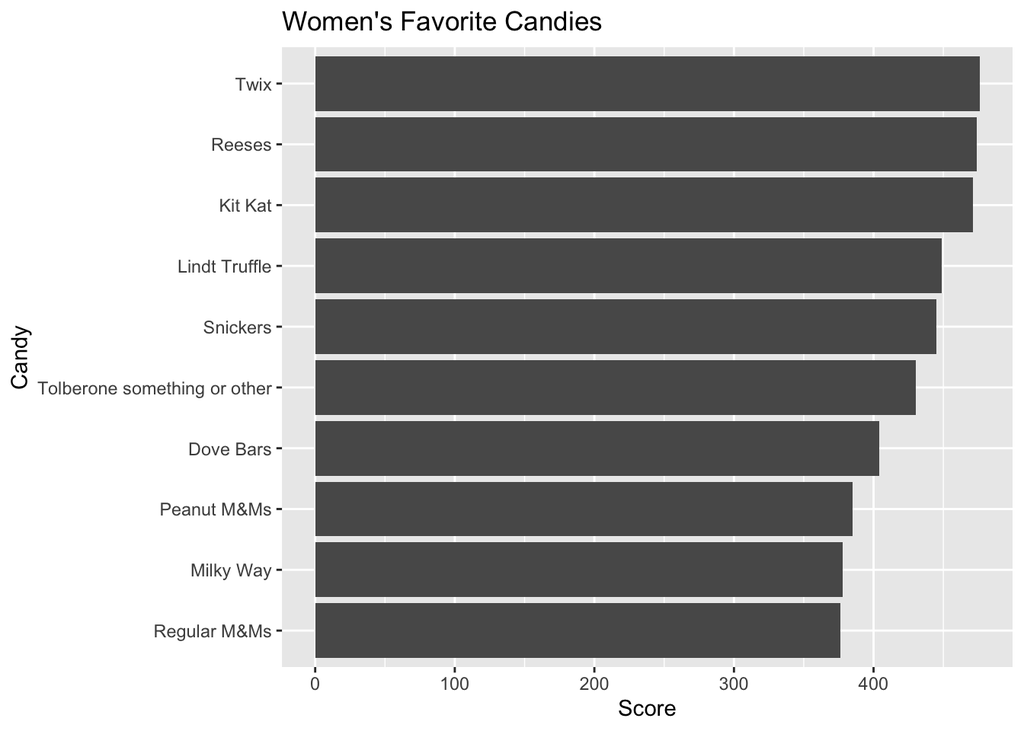

```r
wc %>%
  ggplot(aes(x = fct_reorder(`Candy Type`, Score), y = Score))+
  geom_bar(stat = "identity") +
  ggtitle("Women's Favorite Candies")+
  xlab("Candy")+
  coord_flip()
```

Ultimately, I have not been able to determine meaningful differences in the tastes for women and men of candies. This is useful to a degree because it demonstrates that companies have not wedged the market of sweets into what are “men’s tastes” and “women’s tastes.”

#### Clint

**Clint’s Question:** Does the popularity of candy vary by region or state? Are some candies unviversally popular? The region grouping by which my analysis will be conducted is based off of the nine regions used by the National Climate Data Center.

```r
# gathering states into regions

candy_us <- candy2%>%
  filter(COUNTRY == 'United States', !is.na(Rating))%>%
  group_by(`Candy Type`) %>%
  summarize(Score = sum(Rating)) %>%
  arrange(desc(Score))%>%
  top_n(10)

candy_nwp <- candy2%>%
  filter(COUNTRY == 'United States', State %in% c('Washington', 'Oregon', 'Idaho', 'Alaska', 'Hawaii'), !is.na(Rating))%>%
  group_by(`Candy Type`) %>%
  summarize(Score = sum(Rating)) %>%
  arrange(desc(Score))%>%
  top_n(10)

candy_west <- candy2%>%
  filter(COUNTRY == 'United States', State %in% c('California', 'Nevada'), !is.na(Rating))%>%
  group_by(`Candy Type`) %>%
  summarize(Score = sum(Rating)) %>%
  arrange(desc(Score))%>%
  top_n(10)


candy_sw <- candy2%>%
  filter(COUNTRY == 'United States', State %in% c('Colorado', 'New Mexico', 'Arizona', 'Utah'), !is.na(Rating))%>%
  group_by(`Candy Type`) %>%
  summarize(Score = sum(Rating)) %>%
  arrange(desc(Score))%>%
  top_n(10)


candy_wnc <- candy2%>%
  filter(COUNTRY == 'United States', State %in% c('Wyoming', 'Montana', 'North Dakota', 'South Dakota', 'Nebraska'), !is.na(Rating))%>%
  group_by(`Candy Type`) %>%
  summarize(Score = sum(Rating)) %>%
  arrange(desc(Score))%>%
  top_n(10)


candy_south <- candy2%>%
  filter(COUNTRY == 'United States', State %in% c('Kansas', 'Oklahoma', 'Texas', 'Arkansas', 'Louisiana'), !is.na(Rating))%>%
  group_by(`Candy Type`) %>%
  summarize(Score = sum(Rating)) %>%
  arrange(desc(Score))%>%
  top_n(10)


candy_enc <- candy2%>%
  filter(COUNTRY == 'United States', State %in% c('Wisconsin', 'Iowa', 'Minnesota', 'Michigan'), !is.na(Rating))%>%
  group_by(`Candy Type`) %>%
  summarize(Score = sum(Rating)) %>%
  arrange(desc(Score))%>%
  top_n(10)


candy_central <- candy2%>%
  filter(COUNTRY == 'United States', State %in% c('Missouri', 'Indiana', 'Illinois', 'Ohio', 'Kentucky', 'West Virginia'), !is.na(Rating))%>%
  group_by(`Candy Type`) %>%
  summarize(Score = sum(Rating)) %>%
  arrange(desc(Score))%>%
  top_n(10)


candy_ne <- candy2%>%
  filter(COUNTRY == 'United States', State %in% c('Maryland', 'Delaware', 'New Jersey', 'Pennsylvania', 'New York', 'Connecticut', 'Rhode Island', 'Massechusetts', 'Vermont', 'New Hampshire', 'Maine'), !is.na(Rating))%>%
  group_by(`Candy Type`) %>%
  summarize(Score = sum(Rating)) %>%
  arrange(desc(Score))%>%
  top_n(10)


candy_se <- candy2%>%
  filter(COUNTRY == 'United States', State %in% c('Virginia', 'North Carolina', 'South Carolina', 'Georgia', 'Florida', 'Alabama'), !is.na(Rating))%>%
  group_by(`Candy Type`) %>%
  summarize(Score = sum(Rating)) %>%
  arrange(desc(Score))%>%
  top_n(10)

candy_canada <- candy2%>%
  filter(COUNTRY == 'Canada', !is.na(Rating))%>%
  group_by(`Candy Type`) %>%
  summarize(Score = sum(Rating)) %>%
  arrange(desc(Score))%>%
  top_n(10)

candy_int <- candy2%>%
  filter(COUNTRY != 'United States', COUNTRY != 'Canada', !is.na(Rating))%>%
  group_by(`Candy Type`) %>%
  summarize(Score = sum(Rating)) %>%
  arrange(desc(Score))%>%
  top_n(10)
```

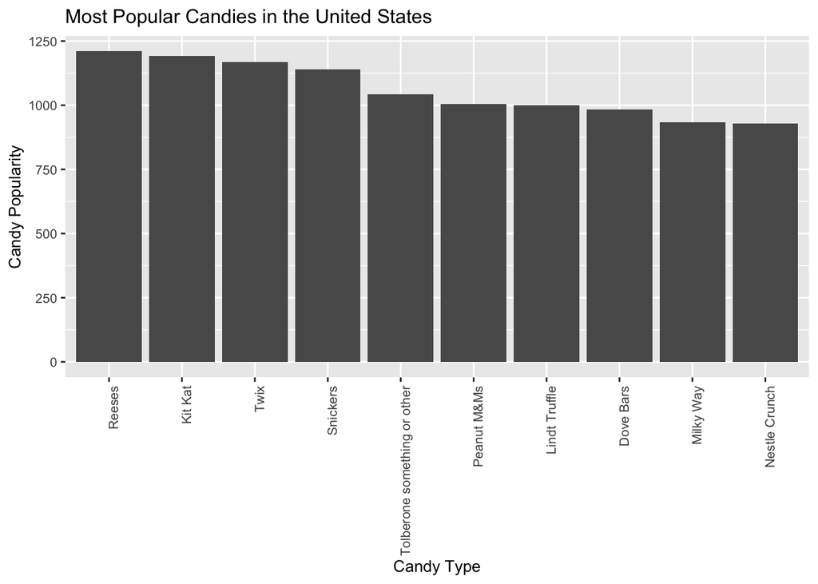

```r
#creating graphs

ggplot(data = candy_us)+
  geom_col(aes(x = reorder(`Candy Type`, -`Score`), y = candy_us$Score)) +  theme(text = element_text(size=10),
        axis.text.x = element_text(angle=90, hjust=1)) +
  ylab("Candy Popularity") +
  ggtitle("Most Popular Candies in the United States")+
  xlab("Candy Type")
```

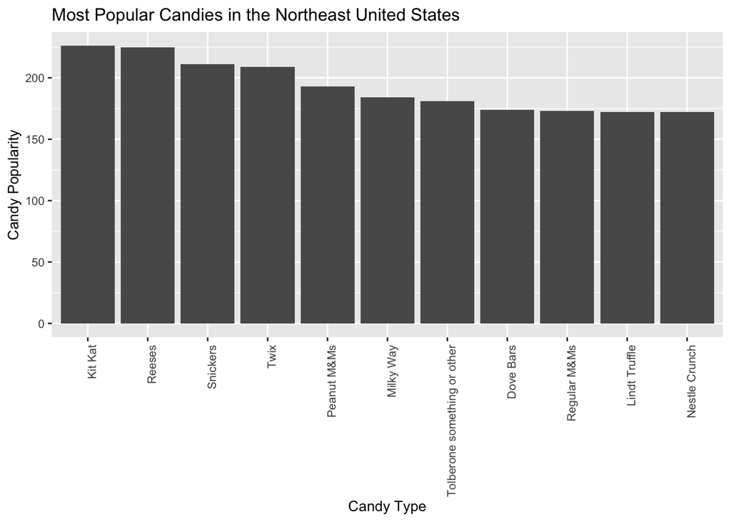

```r
ggplot(data = candy_ne)+
  geom_col(aes(x = reorder(`Candy Type`, -`Score`), y = candy_ne$Score)) +  theme(text = element_text(size=10),
        axis.text.x = element_text(angle=90, hjust=1)) +
  ylab("Candy Popularity") +
  ggtitle("Most Popular Candies in the Northeast United States")+
  xlab("Candy Type")
```

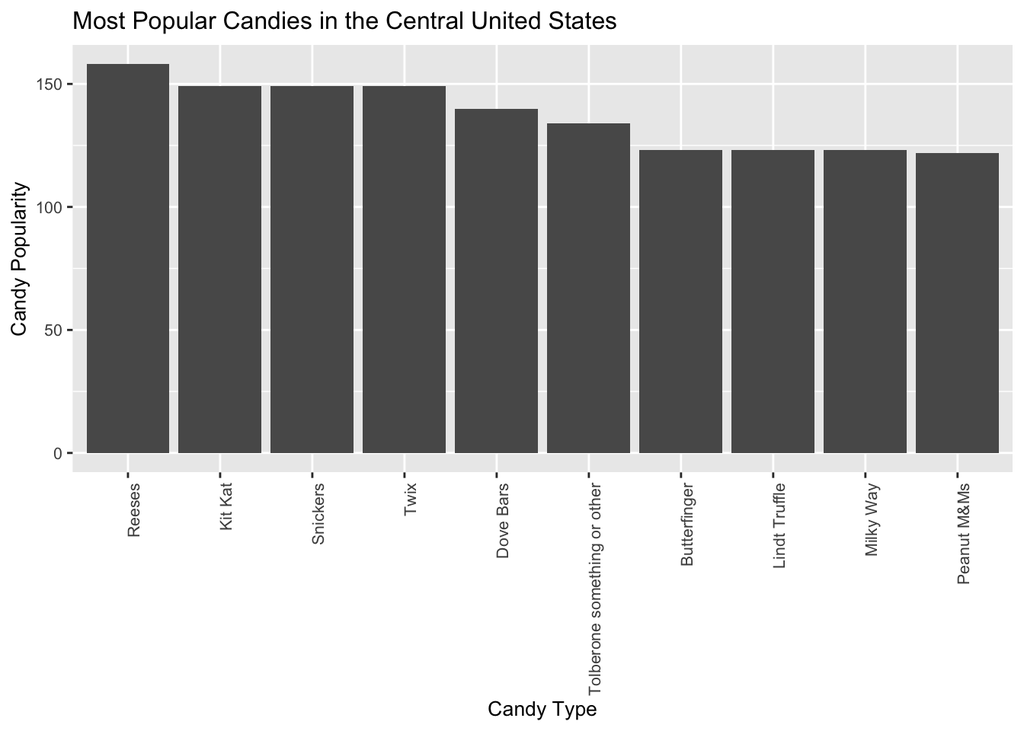

```r
ggplot(data = candy_central)+
  geom_col(aes(x = reorder(`Candy Type`, -`Score`), y = candy_central$Score)) +  theme(text = element_text(size=10),
        axis.text.x = element_text(angle=90, hjust=1)) +
  ylab("Candy Popularity") +
  ggtitle("Most Popular Candies in the Central United States")+
  xlab("Candy Type")
```

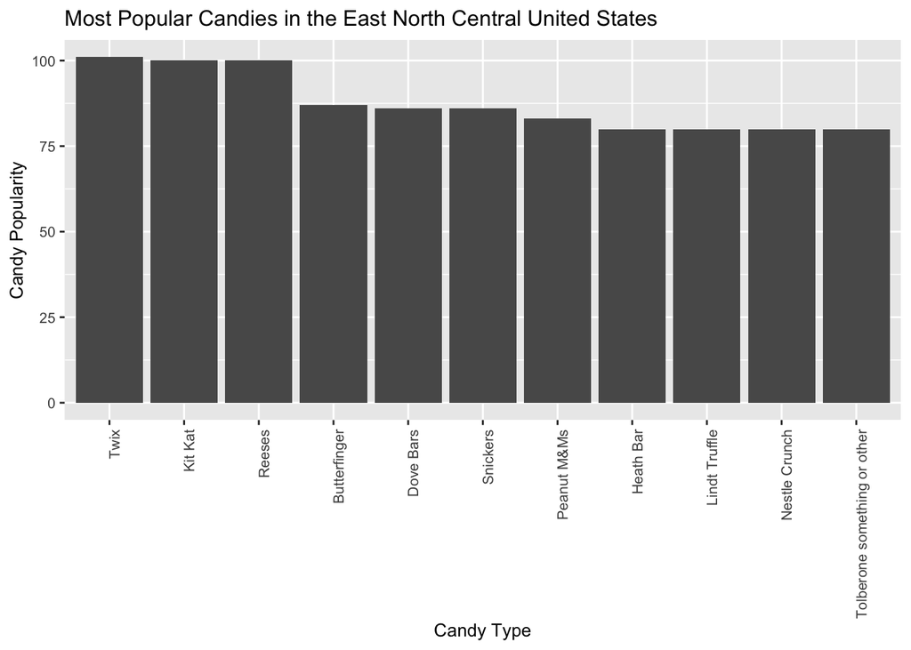

```r
ggplot(data = candy_enc)+
  geom_col(aes(x = reorder(`Candy Type`, -`Score`), y = candy_enc$Score)) +  theme(text = element_text(size=10),
        axis.text.x = element_text(angle=90, hjust=1)) +
  ylab("Candy Popularity") +
  ggtitle("Most Popular Candies in the East North Central United States")+
  xlab("Candy Type")
```

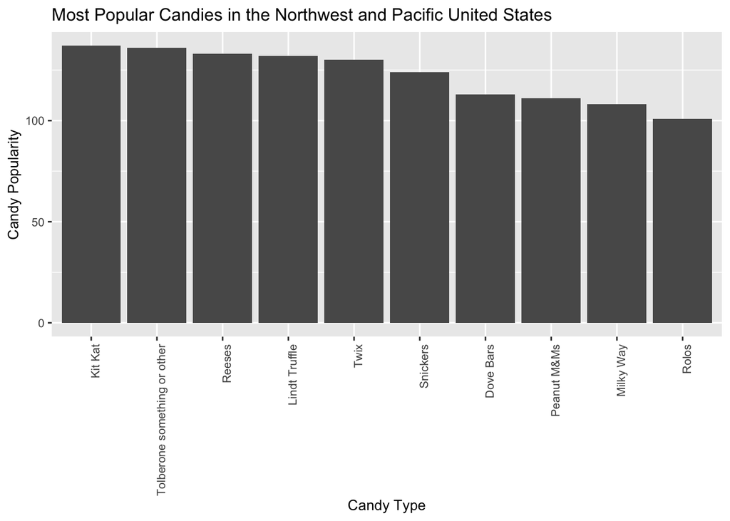

```r
ggplot(data = candy_nwp)+
  geom_col(aes(x = reorder(`Candy Type`, -`Score`), y = candy_nwp$Score)) +  theme(text = element_text(size=10),
        axis.text.x = element_text(angle=90, hjust=1)) +
  ylab("Candy Popularity") +
  ggtitle("Most Popular Candies in the Northwest and Pacific United States")+
  xlab("Candy Type")
```

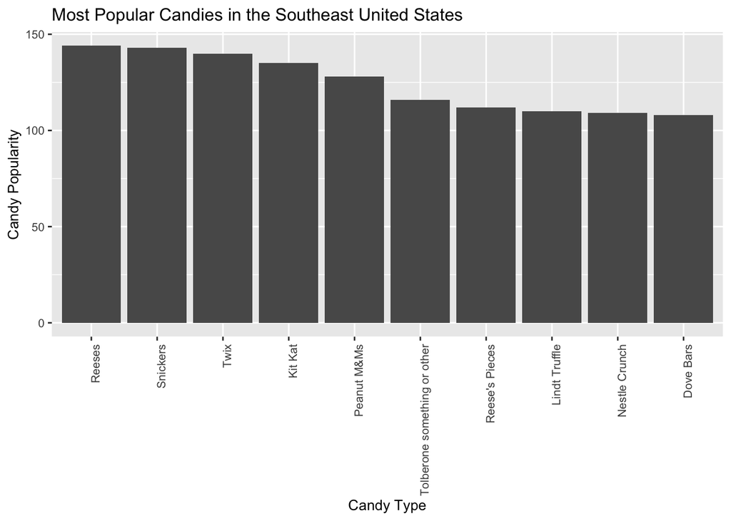

```r
ggplot(data = candy_se)+
  geom_col(aes(x = reorder(`Candy Type`, -`Score`), y = candy_se$Score)) +  theme(text = element_text(size=10),
        axis.text.x = element_text(angle=90, hjust=1)) +
  ylab("Candy Popularity") +
  ggtitle("Most Popular Candies in the Southeast United States")+
  xlab("Candy Type")
```

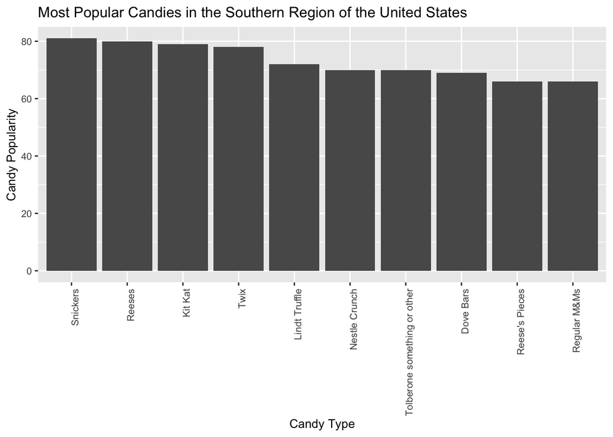

```r
ggplot(data = candy_south)+
  geom_col(aes(x = reorder(`Candy Type`, -`Score`), y = candy_south$Score)) +  theme(text = element_text(size=10),
        axis.text.x = element_text(angle=90, hjust=1)) +
  ylab("Candy Popularity") +
  ggtitle("Most Popular Candies in the Southern Region of the United States") +
  xlab("Candy Type")
```

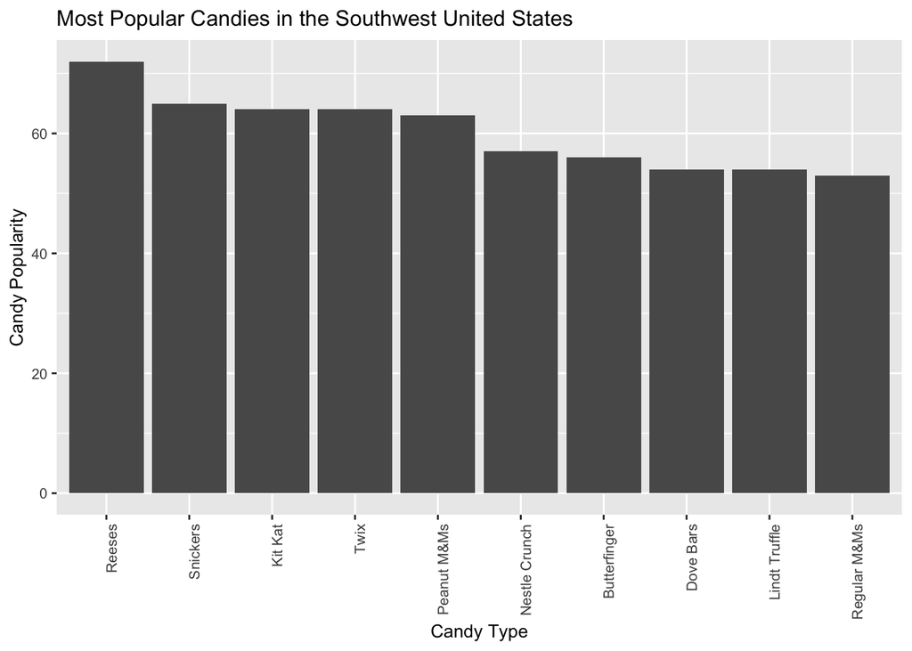

```r
ggplot(data = candy_sw)+
  geom_col(aes(x = reorder(`Candy Type`, -`Score`), y = candy_sw$Score)) +  theme(text = element_text(size=10),
        axis.text.x = element_text(angle=90, hjust=1)) +
  ylab("Candy Popularity") +
  ggtitle("Most Popular Candies in the Southwest United States")+
  xlab("Candy Type")
```

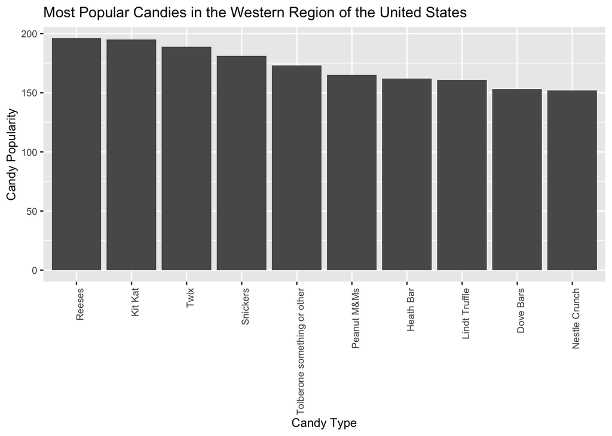

```r
ggplot(data = candy_west)+
  geom_col(aes(x = reorder(`Candy Type`, -`Score`), y = candy_west$Score)) +  theme(text = element_text(size=10),
        axis.text.x = element_text(angle=90, hjust=1)) +
  ylab("Candy Popularity") +
  ggtitle("Most Popular Candies in the Western Region of the United States") +
  xlab("Candy Type")
```

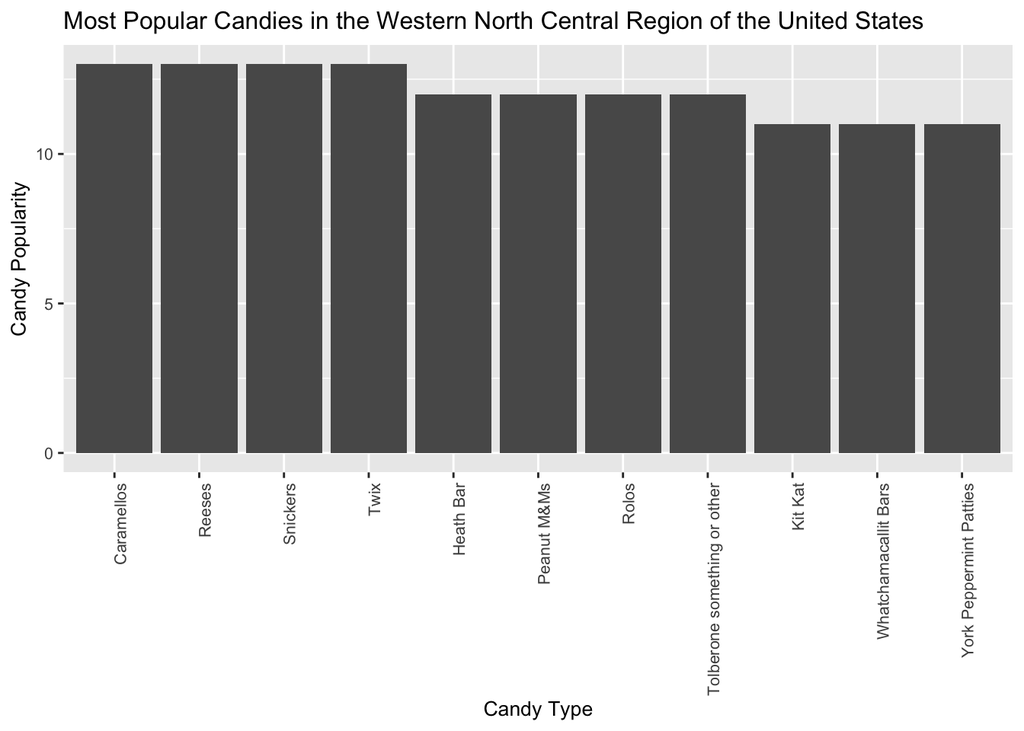

```r
ggplot(data = candy_wnc)+
  geom_col(aes(x = reorder(`Candy Type`, -`Score`), y = candy_wnc$Score)) +  theme(text = element_text(size=10),
        axis.text.x = element_text(angle=90, hjust=1)) +
  ylab("Candy Popularity") +
  ggtitle("Most Popular Candies in the Western North Central Region of the United States") +
  xlab("Candy Type")
```

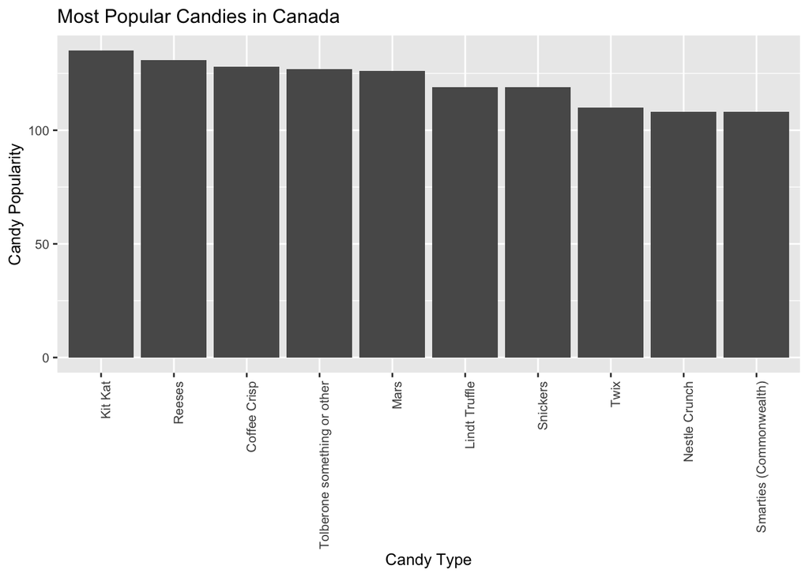

```r
ggplot(data = candy_canada)+
  geom_col(aes(x = reorder(`Candy Type`, -`Score`), y = candy_canada$Score)) +  theme(text = element_text(size=10),
        axis.text.x = element_text(angle=90, hjust=1)) +
  ylab("Candy Popularity") +
  ggtitle("Most Popular Candies in Canada")+
  xlab("Candy Type")
```

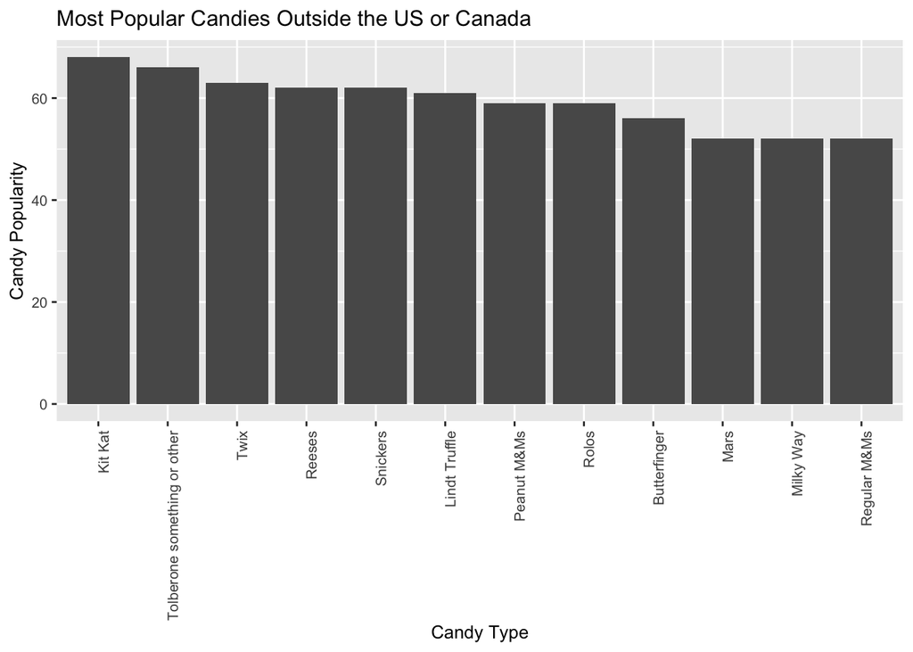

```r
ggplot(data = candy_int)+
geom_col(aes(x = reorder(`Candy Type`, -`Score`), y = candy_int$Score)) +  theme(text = element_text(size=10),
        axis.text.x = element_text(angle=90, hjust=1)) +
  ylab("Candy Popularity") +
  ggtitle("Most Popular Candies Outside the US or Canada") +
  xlab("Candy Type")
```

### Individual Contributions

**Andrew:** I used a clean dataset to analyze the prefered and least favorite candies based upon which country the person was from.

**Brian:** I found the dataset and did the majority of the tidying. I used a variety of joins, mutates, etc. to create some new variables to compare preferences across groups of differing sizes.

**Charles:** I mutated the dataset to view it specifically from the perspectives of gender, and tested to see if gender caused meaningful variations in the preferences of candies.

**Clint::** I used the tidy dataset to filter by regions in the US and then created collumn graphs for each region and for the United States in general. I then compared the graphs to each other and to the US candy popularity graph in general.